# IST 5535 HW4: Problem 13

Sayantan Majumdar

2020-02-17

### (a) Using the rnorm() function, create a vector, x, containing 100 observations drawn from a $N(0, 1)$ distribution. This represents a feature, $X$.

```r
set.seed(1)
x <- rnorm(100)
```

### (b) Using the rnorm() function, create a vector, eps, containing 100 observations drawn from a $N(0, 0.25)$ distribution i.e. a normal distribution with mean zero and variance 0.25.

```r
eps <- rnorm(100, sd = sqrt(0.25))
```

### (c) Using x and eps, generate a vector y according to the model $Y = -1 + 0.5X + \epsilon$ (3.39). What is the length of the vector y? What are the values of $\beta_0$ and $\beta_1$ in this linear model?

```r
y <- -1 + 0.5 * x + eps
```

Length of vector y = 100, $\beta_0=-1$ and $\beta_1=0.5$.

### (d) Create a scatterplot displaying the relationship between x and y. Comment on what you observe.

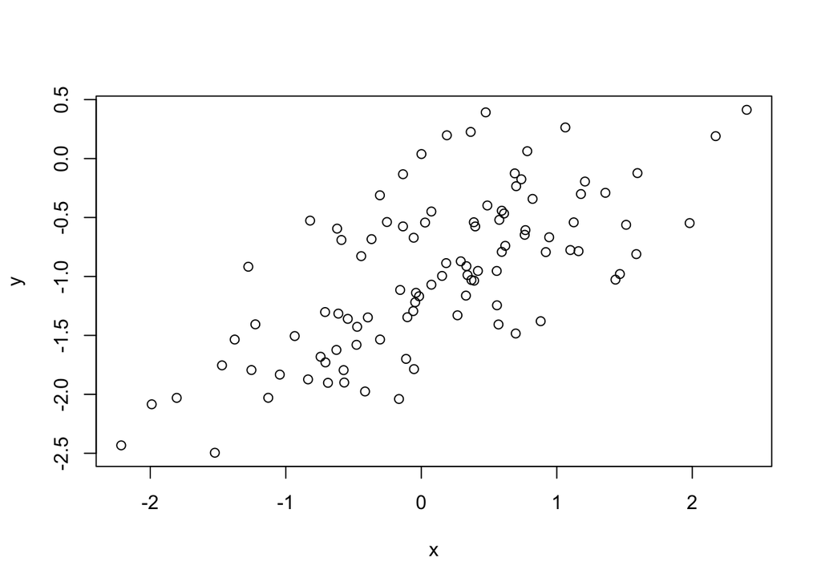

```r
plot(x, y)
```

x and y seems to have a linear relationship but some noise is introduced by eps.

### (e) Fit a least squares linear model to predict y using x. Comment on the model obtained. How do $\hat\beta_0$ and $\hat\beta_1$ compare to $\beta_0$ and $\beta_1$?

```r
lfit1 <- lm(y ~ x)
summary(lfit1)
```

```
##
## Call:
## lm(formula = y ~ x)
##
## Residuals:
##      Min       1Q   Median       3Q      Max
## -0.93842 -0.30688 -0.06975  0.26970  1.17309
##
## Coefficients:
##             Estimate Std. Error t value Pr(>|t|)
## (Intercept) -1.01885    0.04849 -21.010  < 2e-16 ***
## x            0.49947    0.05386   9.273 4.58e-15 ***
## ---
## Signif. codes:  0 '***' 0.001 '**' 0.01 '*' 0.05 '.' 0.1 ' ' 1
##
## Residual standard error: 0.4814 on 98 degrees of freedom
## Multiple R-squared:  0.4674, Adjusted R-squared:  0.4619
## F-statistic: 85.99 on 1 and 98 DF,  p-value: 4.583e-15
```

The estimated $\hat\beta_0$ and $\hat\beta_1$ are quite close to the actual $\beta_0$ and $\beta_1$ respectively. Since the p-values are all less than 0.05, so we can reject the null hypotheses.

### (f) Display the least squares line on the scatterplot obtained in (d). Draw the population regression line on the plot, in a different color. Use the legend() command to create an appropriate legend.

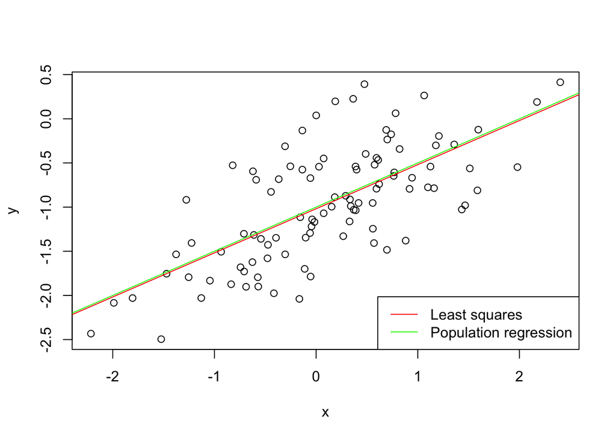

```r
plot(x, y)
abline(lfit1, col = "red")
abline(-1, 0.5, col = "green")
legend("bottomright", c("Least squares", "Population regression"), col = c("red", "green"), lty = c(1, 1))
```

### (g) Now fit a polynomial regression model that predicts y using x and x$^2$. Is there evidence that the quadratic term improves the model fit? Explain your answer.

```r
qfit <- lm(y ~ x + I(x^2))
summary(qfit)
```

```
##
## Call:
## lm(formula = y ~ x + I(x^2))
##
## Residuals:
##      Min       1Q   Median       3Q      Max
## -0.98252 -0.31270 -0.06441  0.29014  1.13500
##
## Coefficients:
##             Estimate Std. Error t value Pr(>|t|)
## (Intercept) -0.97164    0.05883 -16.517  < 2e-16 ***
## x            0.50858    0.05399   9.420  2.4e-15 ***
## I(x^2)      -0.05946    0.04238  -1.403    0.164
## ---
## Signif. codes:  0 '***' 0.001 '**' 0.01 '*' 0.05 '.' 0.1 ' ' 1
##
## Residual standard error: 0.479 on 97 degrees of freedom
## Multiple R-squared:  0.4779, Adjusted R-squared:  0.4672
## F-statistic:  44.4 on 2 and 97 DF,  p-value: 2.038e-14
```

The coefficient for x$^2$ is not statistically significant (p-value > 0.05). Moreover, we have a slight increase and decrease in $R^2$ and RSE values respectively. Therefore, the quadratic term is not signficanty improving the model fit and hence, the linear model is preferred.

### (h) Repeat (a)–(f) after modifying the data generation process in such a way that there is $less$ noise in the data. The model (3.39) should remain the same. You can do this by decreasing the variance of the normal distribution used to generate the error term $\epsilon$ in (b). Describe your results.

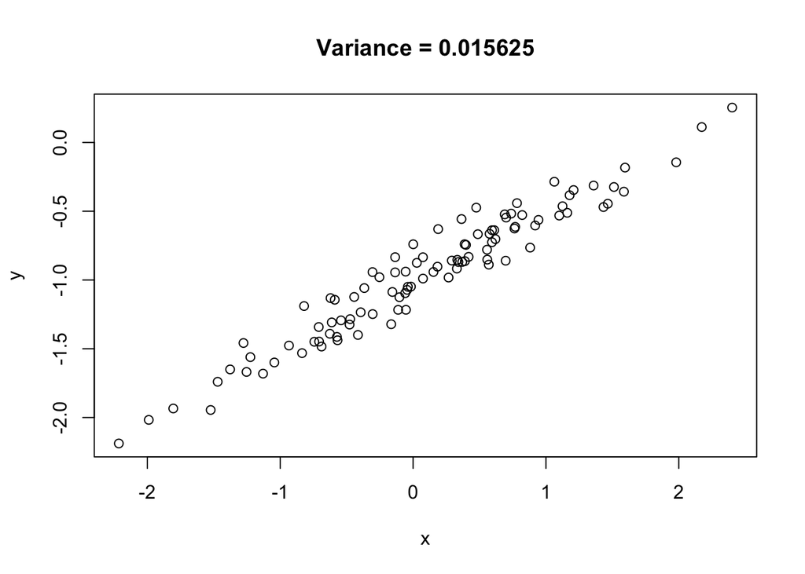

```r
set.seed(1)
x <- rnorm(100)
eps <- rnorm(100, sd = 0.125)
y <- -1 + 0.5 * x + eps
plot(x, y, main=paste('Variance =', 0.125^2))
```

```r
lfit2 <- lm(y ~ x)
summary(lfit2)
```

```
##
## Call:
## lm(formula = y ~ x)
##
## Residuals:
##      Min       1Q   Median       3Q      Max
## -0.23461 -0.07672 -0.01744  0.06742  0.29327
##
## Coefficients:
##             Estimate Std. Error t value Pr(>|t|)
## (Intercept) -1.00471    0.01212  -82.87   <2e-16 ***
## x            0.49987    0.01347   37.12   <2e-16 ***
## ---
## Signif. codes:  0 '***' 0.001 '**' 0.01 '*' 0.05 '.' 0.1 ' ' 1
##
## Residual standard error: 0.1203 on 98 degrees of freedom
## Multiple R-squared:  0.9336, Adjusted R-squared:  0.9329
## F-statistic:  1378 on 1 and 98 DF,  p-value: < 2.2e-16
```

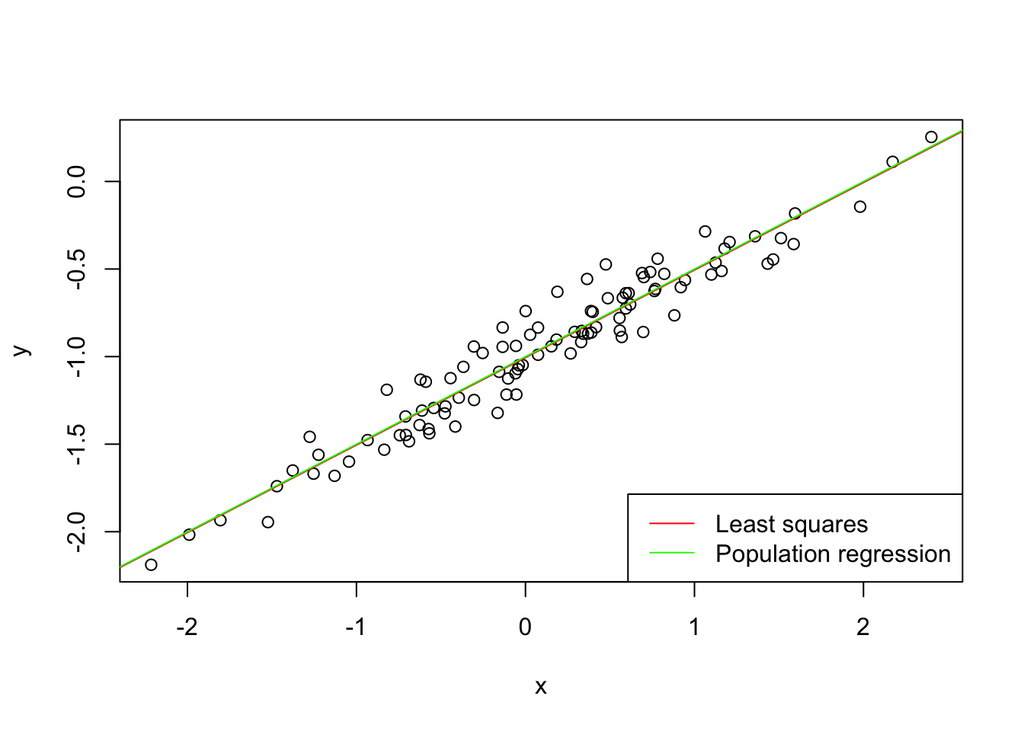

```r
plot(x, y)
abline(lfit2, col = "red")
abline(-1, 0.5, col = "green")
legend("bottomright", c("Least squares", "Population regression"), col = c("red", "green"), lty = c(1, 1))
```

As before, the coefficients are very close to the actual ones. But the linearity has increased and we have a much higher $R^2$ and much lower RSE. Moreover, the population regression and least squares fit lines almost overlap each other due to lower noise.

### (i) Repeat (a)–(f) after modifying the data generation process in such a way that there is $more$ noise in the data. The model (3.39) should remain the same. You can do this by increasing the variance of the normal distribution used to generate the error term $\epsilon$ in (b). Describe your results.

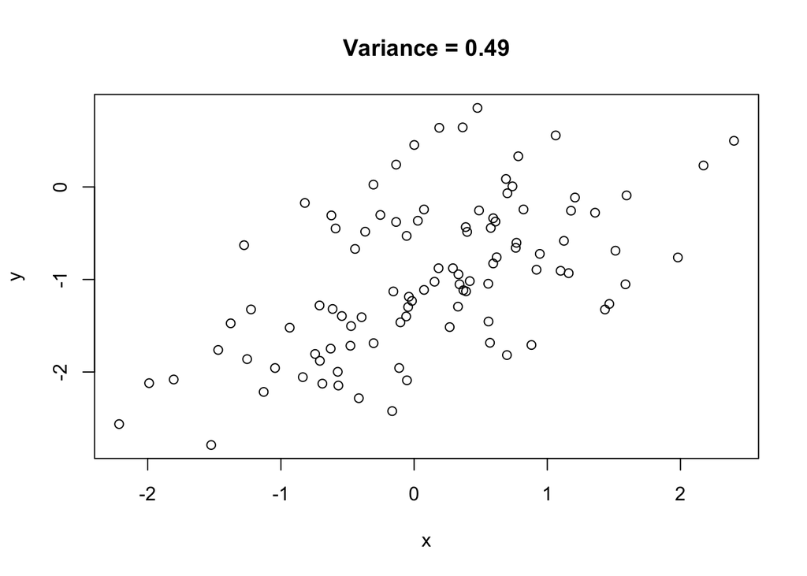

```r
set.seed(1)
x <- rnorm(100)
eps <- rnorm(100, sd = 0.7)
y <- -1 + 0.5 * x + eps
plot(x, y, main=paste('Variance =', 0.7^2))
```

```r
lfit3 <- lm(y ~ x)
summary(lfit3)
```

```
##
## Call:
## lm(formula = y ~ x)
##
## Residuals:
##      Min       1Q   Median       3Q      Max
## -1.31379 -0.42964 -0.09765  0.37758  1.64232
##
## Coefficients:
##             Estimate Std. Error t value Pr(>|t|)
## (Intercept) -1.02638    0.06789 -15.118  < 2e-16 ***
## x            0.49926    0.07541   6.621 1.92e-09 ***
## ---
## Signif. codes:  0 '***' 0.001 '**' 0.01 '*' 0.05 '.' 0.1 ' ' 1
##
## Residual standard error: 0.6739 on 98 degrees of freedom
## Multiple R-squared:  0.309,  Adjusted R-squared:  0.302
## F-statistic: 43.83 on 1 and 98 DF,  p-value: 1.923e-09
```

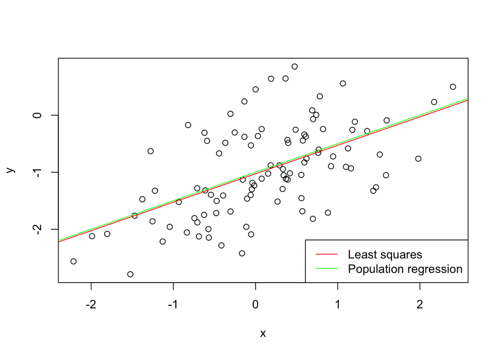

```r
plot(x, y)
abline(lfit3, col = "red")
abline(-1, 0.5, col = "green")
legend("bottomright", c("Least squares", "Population regression"), col = c("red", "green"), lty = c(1, 1))
```

### (j) What are the confidence intervals for $\beta_0$ and $\beta_1$ based on the original data set, the noisier data set, and the less noisy data set? Comment on your results.

```r
c1 <- confint(lfit1)
c2 <- confint(lfit2)
c3 <- confint(lfit3)
stargazer::stargazer(c1, c2, c3, type = 'text')
```

```
##
## =========================
##             2.5 %  97.5 %
## -------------------------
## (Intercept) -1.115 -0.923
## x           0.393  0.606
## -------------------------
##
## =========================
##             2.5 %  97.5 %
## -------------------------
## (Intercept) -1.029 -0.981
## x           0.473  0.527
## -------------------------
##
## =========================
##             2.5 %  97.5 %
## -------------------------
## (Intercept) -1.161 -0.892
## x           0.350  0.649
## -------------------------
```